# First Steps with R: BDSD 2020

Christina Maimone

2020-02-04

All of these materials are available at https://github.com/nuitrcs/r-first-steps to reference later.

# Load the Data

The data set comes from the [GOSSIS Consortium at MIT](https://gossis.mit.edu/). The Global Open Source Severity of Illness Score (GOSSIS) aims to predict in-hospital mortality. The dataset is being used in the Women in Data Science [(WiDS) Kaggle Challenge](https://www.kaggle.com/c/widsdatathon2020). We’re using just a subset of that data here focused on demographics. The dataset also contains lab results, vitals, and other predictors.

## Read In

We’ll start by reading the data into R.

```r
gossis <- read.csv("gossis_subset.csv")
```

## Check

And check to see what variables it contains and how many observataions:

What are the column (variable) names?

```r
names(gossis)
```

```
##  [1] "encounter_id"          "patient_id"
##  [3] "hospital_id"           "hospital_death"
##  [5] "age"                   "bmi"
##  [7] "elective_surgery"      "ethnicity"
##  [9] "gender"                "height"
## [11] "weight"                "hospital_admit_source"
## [13] "icu_stay_type"         "icu_type"
## [15] "pre_icu_los_days"
```

How many variables and observations?

```r
dim(gossis)
```

```
## [1] 91713    15
```

The first number is the number of rows (observations) and the second in the number of columns (variables). We could also use:

```r
nrow(gossis)
ncol(gossis)
```

Look at the data:

```r
View(gossis)
```

# Explore

## Variable Values

### Deaths

How many deaths in the data?

```r
table(gossis$hospital_death)
```

```
##
##     0     1
## 83798  7915
```

As a proportion?

```r
prop.table(table(gossis$hospital_death))
```

```
##
##          0          1
## 0.91369817 0.08630183
```

The results of the call to the inside function (`table`) are sent as input to the outside function (`prop.table`).

### Gender

```r
table(gossis$gender)
```

```
##
##     F     M
## 42219 49469
```

### Check for Missing Data

`NA` stands for missing data in R. Let’s see if there are missing values in any of our variables. `summary()` gives us basic stats about each variable, including a count of missing values:

```r
summary(gossis)
```

```
##   encounter_id      patient_id      hospital_id    hospital_death
##  Min.   :     1   Min.   :     1   Min.   :  2.0   Min.   :0.0000
##  1st Qu.: 32852   1st Qu.: 32830   1st Qu.: 47.0   1st Qu.:0.0000
##  Median : 65665   Median : 65413   Median :109.0   Median :0.0000
##  Mean   : 65606   Mean   : 65537   Mean   :105.7   Mean   :0.0863
##  3rd Qu.: 98342   3rd Qu.: 98298   3rd Qu.:161.0   3rd Qu.:0.0000
##  Max.   :131051   Max.   :131051   Max.   :204.0   Max.   :1.0000
##
##       age             bmi        elective_surgery            ethnicity
##  Min.   :16.00   Min.   :14.85   Min.   :0.0000   African American: 9547
##  1st Qu.:52.00   1st Qu.:23.64   1st Qu.:0.0000   Asian           : 1129
##  Median :65.00   Median :27.66   Median :0.0000   Caucasian       :70684
##  Mean   :62.31   Mean   :29.19   Mean   :0.1837   Hispanic        : 3796
##  3rd Qu.:75.00   3rd Qu.:32.93   3rd Qu.:0.0000   Native American :  788
##  Max.   :89.00   Max.   :67.81   Max.   :1.0000   Other/Unknown   : 4374
##  NA's   :4228    NA's   :3429                     NA's            : 1395
##   gender          height          weight
##  F   :42219   Min.   :137.2   Min.   : 38.60
##  M   :49469   1st Qu.:162.5   1st Qu.: 66.80
##  NA's:   25   Median :170.1   Median : 80.30
##               Mean   :169.6   Mean   : 84.03
##               3rd Qu.:177.8   3rd Qu.: 97.10
##               Max.   :195.6   Max.   :186.00
##               NA's   :1334    NA's   :2720
##           hospital_admit_source  icu_stay_type           icu_type
##  Emergency Department:36962     admit   :86183   Med-Surg ICU:50586
##  Operating Room      : 9787     readmit :  560   MICU        : 7695
##  Floor               : 8055     transfer: 4970   Neuro ICU   : 7675
##  Direct Admit        : 6441                      CCU-CTICU   : 7156
##  Recovery Room       : 2896                      SICU        : 5209
##  (Other)             : 6163                      Cardiac ICU : 4776
##  NA's                :21409                      (Other)     : 8616
##  pre_icu_los_days
##  Min.   :-24.94722
##  1st Qu.:  0.03542
##  Median :  0.13889
##  Mean   :  0.83577
##  3rd Qu.:  0.40903
##  Max.   :159.09097
##
```

Yep! There are missing values for gender.

There are multiple R packages (sets of functions) that help summarize datasets. One such package is called summarytools. First, to use a package we’d need to install it once for a given computer and version of R. In the session, this has already been done. Second, we need to load it each time we run R and want to use it. The `library()` function loads an installed package.

Normally, we want to put any `library()` statements at the top of the file. This lets people know what packages are needed to run the code.

```r
library(summarytools)  # normally put this at the top of your file
```

This is a package someone wrote to solve a problem! You could write one too, or help improve this one. Code is at https://github.com/dcomtois/summarytools.

Now, we can use one of the functions in summarytools:

```r
dfSummary(gossis)
```

The output in the console can be a little tough to read for large datasets, or if our console isn’t very wide. But it also makes a nice html table:

```r
# When working in R:
view(dfSummary(gossis, valid.col = FALSE))
```

```r
# When producing an HTML file from R Markdown
view(dfSummary(gossis, valid.col = FALSE), method="render")
```

Data Frame Summary

gossis

**Dimensions**: 91713 x 15  
**Duplicates**: 0

| **No** | **Variable** | **Stats / Values** | **Freqs (% of Valid)** | **Missing** |
| --- | --- | --- | --- | --- |
| 1 | encounter_id [integer] | Mean (sd) : 65606.1 (37795.1) min < med < max: 1 < 65665 < 131051 IQR (CV) : 65490 (0.6) | 91713 distinct values | 0 (0%) |
| 2 | patient_id [integer] | Mean (sd) : 65537.1 (37811.3) min < med < max: 1 < 65413 < 131051 IQR (CV) : 65468 (0.6) | 91713 distinct values | 0 (0%) |
| 3 | hospital_id [integer] | Mean (sd) : 105.7 (62.9) min < med < max: 2 < 109 < 204 IQR (CV) : 114 (0.6) | 147 distinct values | 0 (0%) |
| 4 | hospital_death [integer] | Min : 0 Mean : 0.1 Max : 1 | 0 : 83798 ( 91.4% ) 1 : 7915 ( 8.6% ) | 0 (0%) |
| 5 | age [integer] | Mean (sd) : 62.3 (16.8) min < med < max: 16 < 65 < 89 IQR (CV) : 23 (0.3) | 74 distinct values | 4228 (4.61%) |
| 6 | bmi [numeric] | Mean (sd) : 29.2 (8.3) min < med < max: 14.8 < 27.7 < 67.8 IQR (CV) : 9.3 (0.3) | 34888 distinct values | 3429 (3.74%) |
| 7 | elective_surgery [integer] | Min : 0 Mean : 0.2 Max : 1 | 0 : 74862 ( 81.6% ) 1 : 16851 ( 18.4% ) | 0 (0%) |
| 8 | ethnicity [factor] | 1. African American 2. Asian 3. Caucasian 4. Hispanic 5. Native American 6. Other/Unknown | 9547 ( 10.6% ) 1129 ( 1.2% ) 70684 ( 78.3% ) 3796 ( 4.2% ) 788 ( 0.9% ) 4374 ( 4.8% ) | 1395 (1.52%) |
| 9 | gender [factor] | 1. F 2. M | 42219 ( 46.1% ) 49469 ( 53.9% ) | 25 (0.03%) |
| 10 | height [numeric] | Mean (sd) : 169.6 (10.8) min < med < max: 137.2 < 170.1 < 195.6 IQR (CV) : 15.3 (0.1) | 401 distinct values | 1334 (1.45%) |
| 11 | weight [numeric] | Mean (sd) : 84 (25) min < med < max: 38.6 < 80.3 < 186 IQR (CV) : 30.3 (0.3) | 3409 distinct values | 2720 (2.97%) |
| 12 | hospital_admit_source [factor] | 1. Acute Care/Floor 2. Chest Pain Center 3. Direct Admit 4. Emergency Department 5. Floor 6. ICU 7. ICU to SDU 8. Observation 9. Operating Room 10. Other [ 5 others ] | 1910 ( 2.7% ) 134 ( 0.2% ) 6441 ( 9.2% ) 36962 ( 52.6% ) 8055 ( 11.5% ) 35 ( 0.0% ) 45 ( 0.1% ) 10 ( 0.0% ) 9787 ( 13.9% ) 7 ( 0.0% ) 6918 ( 9.8% ) | 21409 (23.34%) |
| 13 | icu_stay_type [factor] | 1. admit 2. readmit 3. transfer | 86183 ( 94.0% ) 560 ( 0.6% ) 4970 ( 5.4% ) | 0 (0%) |
| 14 | icu_type [factor] | 1. Cardiac ICU 2. CCU-CTICU 3. CSICU 4. CTICU 5. Med-Surg ICU 6. MICU 7. Neuro ICU 8. SICU | 4776 ( 5.2% ) 7156 ( 7.8% ) 4613 ( 5.0% ) 4003 ( 4.4% ) 50586 ( 55.2% ) 7695 ( 8.4% ) 7675 ( 8.4% ) 5209 ( 5.7% ) | 0 (0%) |
| 15 | pre_icu_los_days [numeric] | Mean (sd) : 0.8 (2.5) min < med < max: -24.9 < 0.1 < 159.1 IQR (CV) : 0.4 (3) | 9757 distinct values | 0 (0%) |

Generated by summarytools 0.9.4 ([R](https://www.r-project.org/) version 3.6.0)  
2020-02-03

```r
# When working in R:
view(descr(gossis, transpose=TRUE, stats="common"))
```

```r
# When producing an HTML file from R Markdown
view(descr(gossis, transpose=TRUE, stats="common"), method="render")
```

```
## Non-numerical variable(s) ignored: ethnicity, gender, hospital_admit_source, icu_stay_type, icu_type
```

Descriptive Statistics

gossis

**N**: 91713

|  | Mean | Std.Dev | Min | Median | Max | N.Valid | Pct.Valid |
| --- | --- | --- | --- | --- | --- | --- | --- |
| **age** | 62.31 | 16.78 | 16.00 | 65.00 | 89.00 | 87485 | 95.39 |
| **bmi** | 29.19 | 8.28 | 14.84 | 27.65 | 67.81 | 88284 | 96.26 |
| **elective_surgery** | 0.18 | 0.39 | 0.00 | 0.00 | 1.00 | 91713 | 100.00 |
| **encounter_id** | 65606.08 | 37795.09 | 1.00 | 65665.00 | 131051.00 | 91713 | 100.00 |
| **height** | 169.64 | 10.80 | 137.20 | 170.10 | 195.59 | 90379 | 98.55 |
| **hospital_death** | 0.09 | 0.28 | 0.00 | 0.00 | 1.00 | 91713 | 100.00 |
| **hospital_id** | 105.67 | 62.85 | 2.00 | 109.00 | 204.00 | 91713 | 100.00 |
| **patient_id** | 65537.13 | 37811.25 | 1.00 | 65413.00 | 131051.00 | 91713 | 100.00 |
| **pre_icu_los_days** | 0.84 | 2.49 | -24.95 | 0.14 | 159.09 | 91713 | 100.00 |
| **weight** | 84.03 | 25.01 | 38.60 | 80.30 | 186.00 | 88993 | 97.03 |

Generated by summarytools 0.9.4 ([R](https://www.r-project.org/) version 3.6.0)  
2020-02-03

### Remove Rows with Missing Gender

Let’s change our dataset to remove observations where gender is missing (which may not be a good analysis decision!)

```r
gossis <- gossis[!is.na(gossis$gender),]
```

There’s a lot in that statement:

- `is.na()` is a function that returns `TRUE` for each missing value.
- `!` is the symbol for NOT in R
- `!is.na(gossis$gender)` selects observations that aren’t missing
- Square brackets `[]` let us select only part of our data frame
- Inside square brackets, we have `[rows, columns]`. If one part is blank, it means we want all rows or all columns
- `gossis[!is.na(gossis$gender),]` selects from `gossis` only rows where the value of `gossis$gender` isn’t missing
- Then we overwrite our variable `gossis` to now refer to only the subset without missing values of gender.
- Right-side of the assignment happens first, so this works

### Deaths and Gender

Do men and women die at different rates?

```r
prop.table(table(gossis$gender, gossis$hospital_death), margin=2)
```

```
##
##             0         1
##   F 0.4593882 0.4718604
##   M 0.5406118 0.5281396
```

Or prettier table with counts and proportions with `ctable` function from `summarytools`:

```r
ctable(gossis$gender, gossis$hospital_death)
```

```
## Cross-Tabulation, Row Proportions
## gender * hospital_death
## Data Frame: gossis
##
## -------- ---------------- --------------- ------------- ----------------
##            hospital_death               0             1            Total
##   gender
##        F                    38488 (91.2%)   3731 (8.8%)   42219 (100.0%)
##        M                    45293 (91.6%)   4176 (8.4%)   49469 (100.0%)
##    Total                    83781 (91.4%)   7907 (8.6%)   91688 (100.0%)
## -------- ---------------- --------------- ------------- ----------------
```

## T-test

Test the difference with a t-test. The syntax here is `variable to test ~ grouping variable`

```r
t.test(gossis$hospital_death ~ gossis$gender)
```

```
##
##  Welch Two Sample t-test
##
## data:  gossis$hospital_death by gossis$gender
## t = 2.1235, df = 88831, p-value = 0.03371
## alternative hypothesis: true difference in means is not equal to 0
## 95 percent confidence interval:
##  0.0003046097 0.0076074511
## sample estimates:
## mean in group F mean in group M
##      0.08837253      0.08441650
```

# Plot the Data

We’ll use the `ggplot2` package here for visualization. You don’t have to use `ggplot2`, but I recommend it for many applications.

```r
library(ggplot2)  # normally put this at the top of your file
```

## Make a Bar Plot

Plot distribution of `hospital_death`

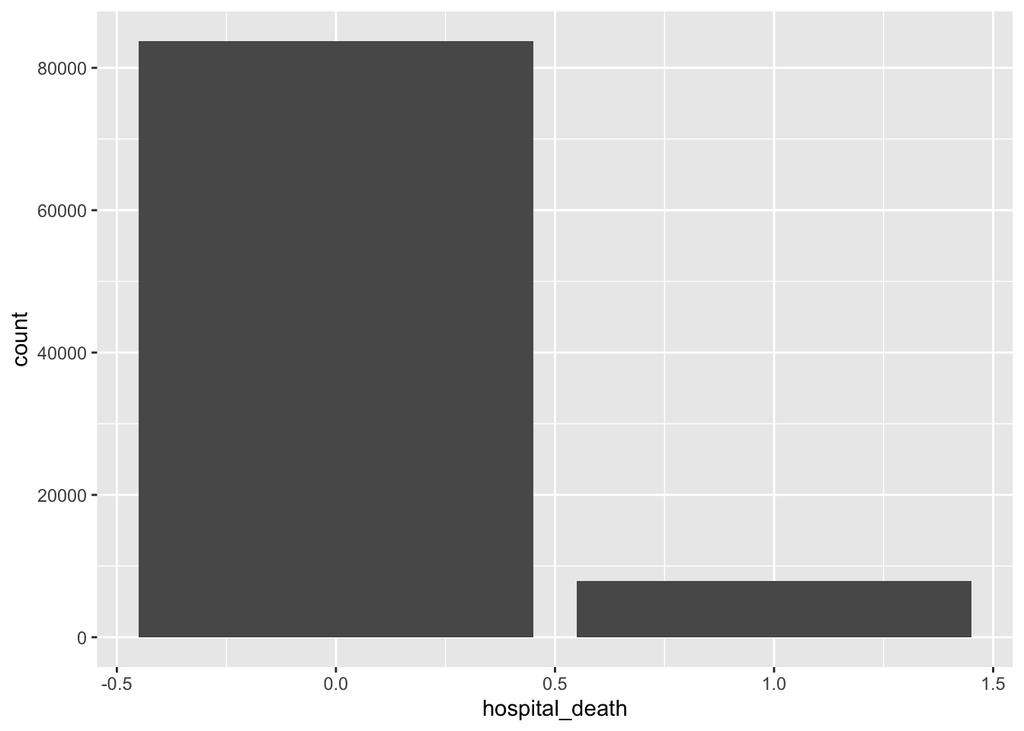

```r
ggplot(gossis, aes(x=hospital_death)) +  # what data and variables to use
  geom_bar()  # what type of plot to make
```

Let’s split by gender

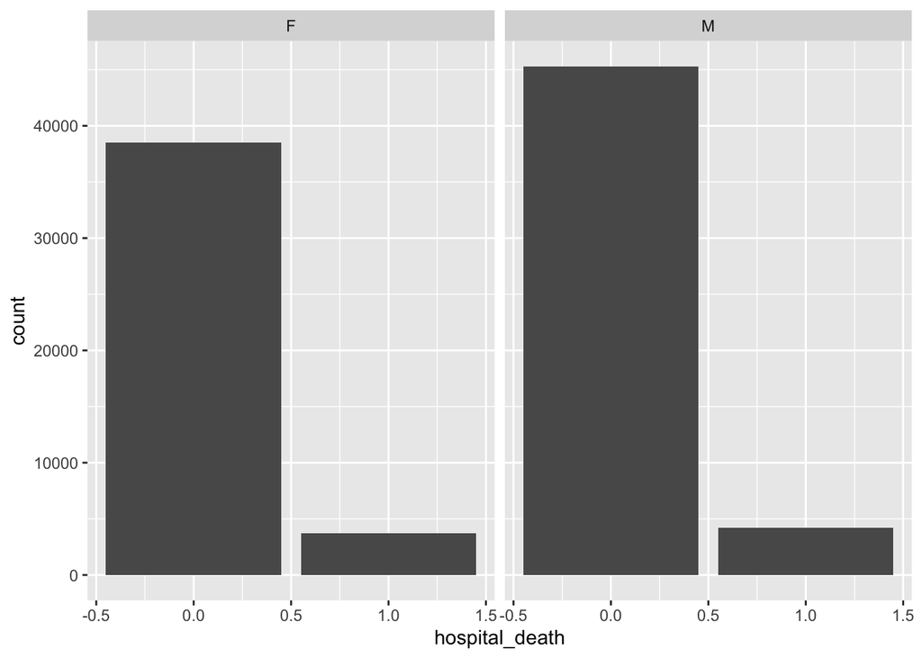

```r
ggplot(gossis, aes(x=hospital_death)) +
  geom_bar() +
  facet_wrap(gender ~ .)  # make a separate plot for each gender
```

## Cleaner Plot

To clean this up for better presentation, we need to add some elements to the plot. Let’s also plot proportion instead of counts

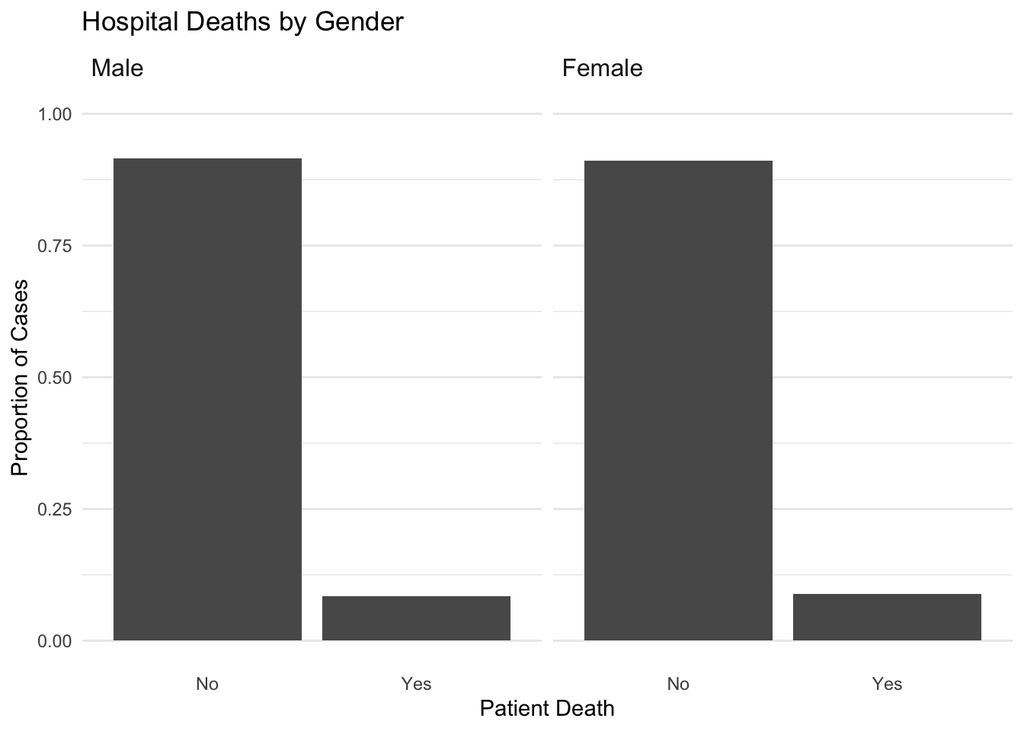

```r
# make the two variables categorical with better labels
gossis$gender <- factor(gossis$gender,
                        levels=c("M", "F"),
                        labels=c("Male", "Female"))
gossis$hospital_death <- factor(gossis$hospital_death,
                                levels=c(0, 1),
                                labels=c("No", "Yes"))

# style and label the plot
ggplot(gossis, aes(x=hospital_death)) +
  geom_bar(aes(y=stat(prop), group=1)) +  # change to plot proportion instead of count
  facet_wrap(gender ~ .)  +
  labs(x="Patient Death", y="Proportion of Cases", title="Hospital Deaths by Gender") + # labels
  scale_y_continuous(limits = c(0,1)) +  # y-axis limits
  theme_minimal() +  # base styling
  theme(panel.grid.major.x = element_blank(),  # remove vertical grid lines
        panel.grid.minor.x = element_blank(),  # remove vertical grid lines
        strip.text = element_text(size=12, hjust=0))  # style Male and Female labels
```

The “No” proportion is redundant if you have the “Yes”, and removing it would make it easier to compare proportions by gender. But to make that plot, we’d need to do more data manipulation, which we don’t have time for here!